# Integrating Wildfire Protection

Lilli Toone, Patricia Ma, Rachel He

11/10/2022

# Integrating Wildfire Protection: Exploratory Data Analysis

### Dynamic summary

We examined the summary of ages, the rate of seeking wildfire-related information, the preferred method to receive updating messages, and the perception of wildfire as a natural hazard of our survey data file. Knowing the age range of our data set helped us determine if our data set represented the general population. The respondents of the survey were, on average, **42 years old**. The maximum age was **84 years old**, and the minimum age was **16 years old**. These participants rated their own general well-being on a scale of 1 to 4, with 1 being the best health. Of those with excellent health, **68.9%** reported that they actively seek information about wildfire and smoke information. Of those with poor health, **71.4%** reported seeking out information for that same question. Understanding these percentages is helpful when determining if a solution must focus attention on certain health groups. We assessed how participants preferred to receive updates on wildfire hazards to find desirable solutions. Receiving updates through **emergency alert** was the most popular, with **338 votes**. We determined that **78.2%** of participants considered wildfires to be a natural hazard, which helped us to understand if wildfire hazards are a widespread worry.

### Table

**Table 1.** PMI Levels By Room.

| room | mean_typ | mean_ff |
| --- | --- | --- |
| fMoffice | 348.5600046 | 358.45811 |
| fhotdesk1 | 299.7223342 | 349.68079 |
| ww232 | 225.6211623 | 260.70859 |
| ww373a | 153.5721979 | 177.70210 |
| ww373c | 131.6884551 | 105.75537 |
| ww353 | 114.0899654 | 154.82017 |
| ww390a | 98.7547540 | 126.72223 |
| ww250a | 97.7753958 | 129.53594 |
| ww390d | 97.7357794 | 133.67305 |
| ww348 | 86.0041217 | 130.53496 |
| foutside | 14.2103553 | 114.49232 |
| woutside | 8.3665716 | 91.01798 |
| wC373c | 2.8158724 | 59.69251 |
| finside | 1.4354881 | 28.56967 |
| fPoffice | 1.0902948 | 42.30925 |
| fcorridor2 | 0.7283520 | 36.48904 |
| fcubicle3 | 0.5605991 | 36.07072 |
| fpantry | 0.5088505 | 35.50992 |
| fcubiclecorner | 0.3717692 | 26.94649 |
| ffloor2mid | 0.3379727 | 33.00561 |
| fcorridor1 | 0.3025493 | 29.64299 |
| fcubiclehotdesk | 0.2617694 | 28.70374 |
| fhotdesk2 | 0.2102704 | 29.88553 |
| ffloor2wall | 0.1910193 | 28.00370 |
| femptyfloor | 0.1528417 | 28.27563 |

### Charts

#### Chart 1: Actions to Protect

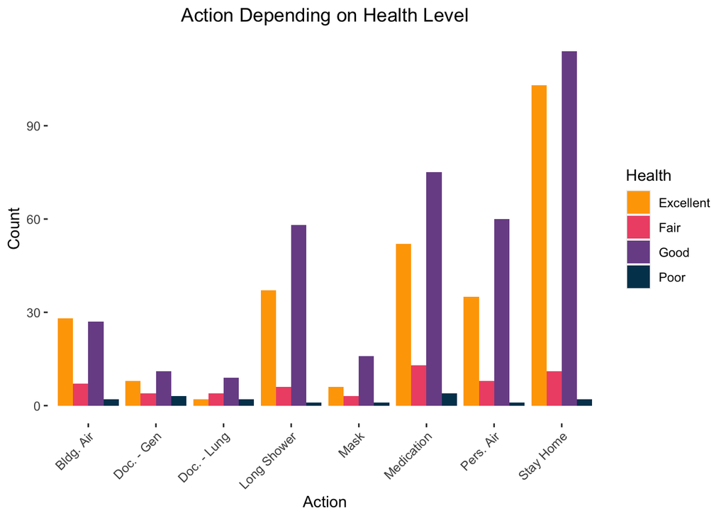

**Figure 1.** Actions that individuals take to protect against wildfire smoke.

#### Chart 2: rooms’ resistance to wildfire smoke

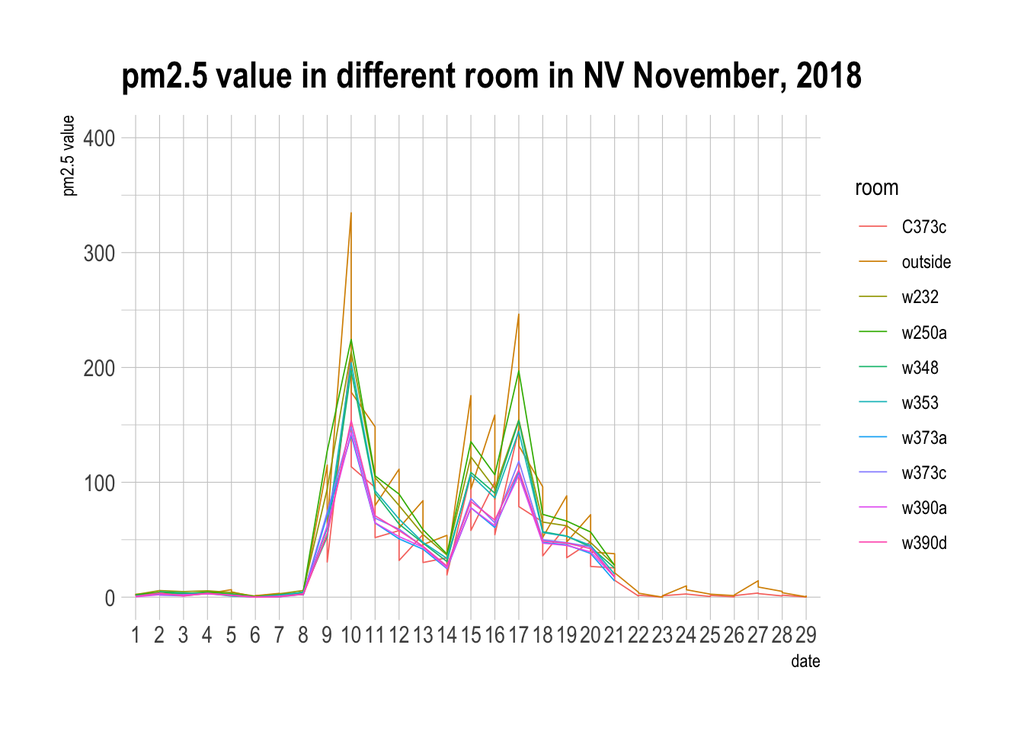

**Figure 2.** Rooms’ measured air quality in wildfire smoke.

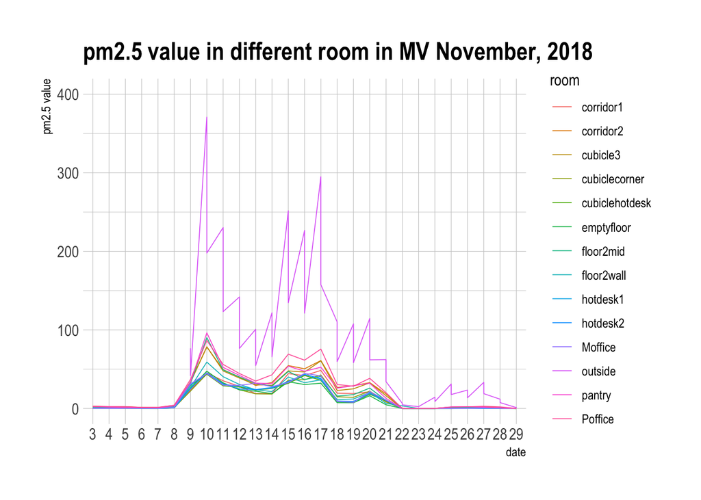

**Figure 3.** Rooms’ measured air quality in wildfire smoke, continued.

This data is collected by measuring the value of pm2.5 inside several rooms in NV and MV and outside during an increase in wildfire smoke. This chart compares different rooms’ resistance when facing pollutants in the air between the two areas each days in November 2018, which reveals rooms in MV are more resistant to smoke since the pm2.5 value inside each rooms are much lower than the value outside. Particularly hotdesk1 and hotdesk2 are the most resistant room. In NV, the most stable and resistant room type is C373c. The chart provides scientific evidence of the room types that should be encouraged to build in specific region.

#### Chart 3

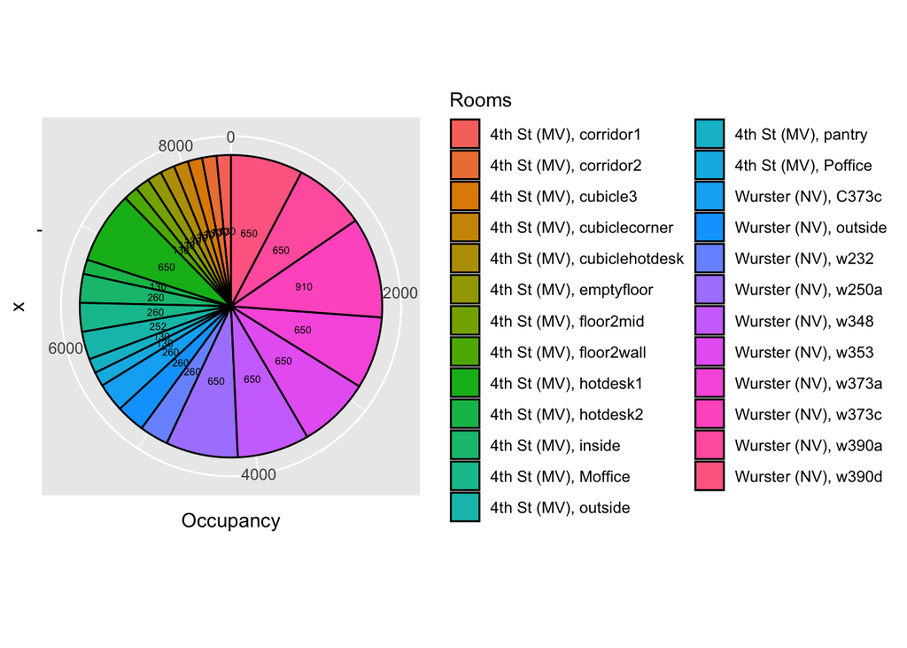

**Figure 4.** Room occupancy during wildfires.

This pie chart is used to answer our third research question regarding which rooms people feel the safest to go into during forest fire as air quality decreases. The data came from our data set that examined people’s choice of indoor rooms during certain periods of time. The chart shows the occupancy rate of each room when wildfires occurs, and the pie chart was chosen to show proportion. We noticed that a few rooms have the exact same occupancy rate, and some rooms are significantly more frequently occupied than others. Viewers can clearly distinguish people’s gravitation towards each room in this chart as rooms are labeled.